# Some fun analysis of radio songs

## Looking at that relationship between Spotify streams and chart points

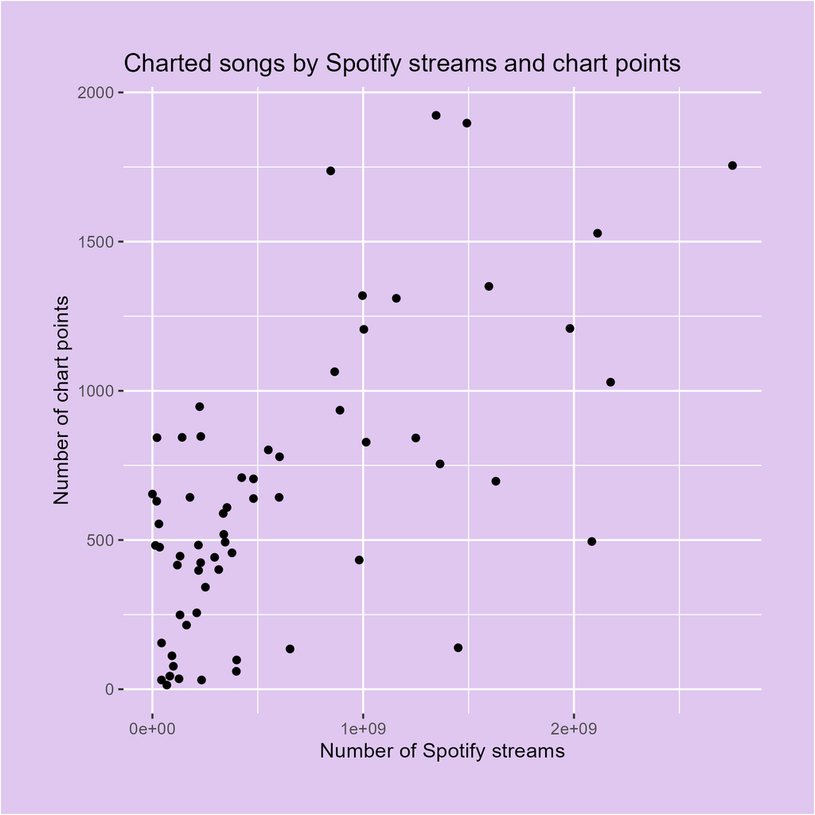

Firstly, I wanted to look at all charted songs and how they placed in terms of their Spotify streams and their chart points(how successful a song’s run in the charts was). From looking at this plot, it looks like that there is some evidence of a positive relationship between Spotify streams and chart points. This makes a lot of sense since songs that have been streamed a lot would have been popular when it was charting (e.g. it gained a lot of streams from earning a lot of chart points by being at #1). However, for more successful songs, there is a lot more variation at the upper section of the plot. This could be because a song wasn’t given too much attention when released but has since become a classic and therefore streamed a lot now. It could also be that a massive selling hit from e.g. the 1990s has faded its star by today.

## Which decade is the most popular for those Spotify lovers?

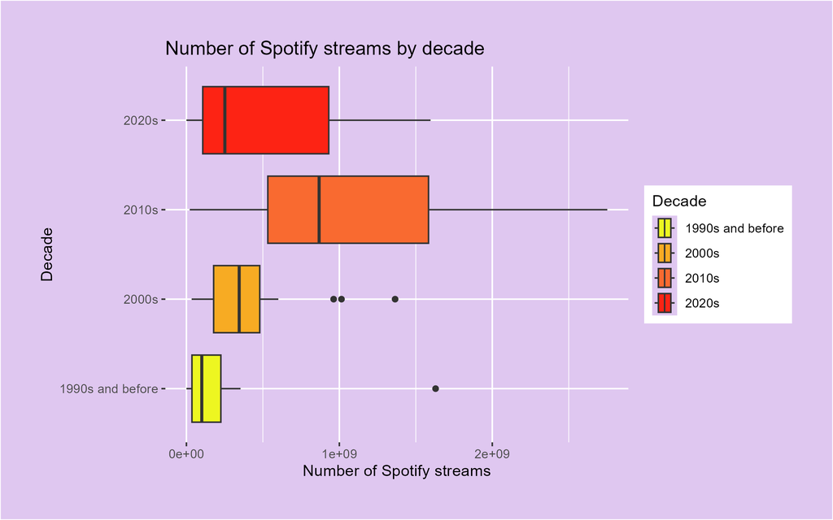

Here, I was interested in how each decade’s group of songs compared to each other in terms of Spotify streams. Personally, I thought that the 2010s and 2020s groups would be streamed more than the 2000s and 1990s and before groups, and I thought this would’ve been due to the 2010s and 2020s being during the height of the popularity of Spotify. Overall, I was fairly correct with my prediction, but wow oh wow, the 2010s is superior even compared to the current decade 2020s. This might have been due to The Hits playing the biggest hits, and that radio station plays a good number of 2010s songs. It’s also likely because songs from the 2020s are much more recent and therefore haven’t had as much time on the beloved platform known as Spotify. The 1990s and before is the lowest mainly due to Spotify not being available during that decade.

## Which radio station loves playing more songs with tongue-twisting titles compared to others?

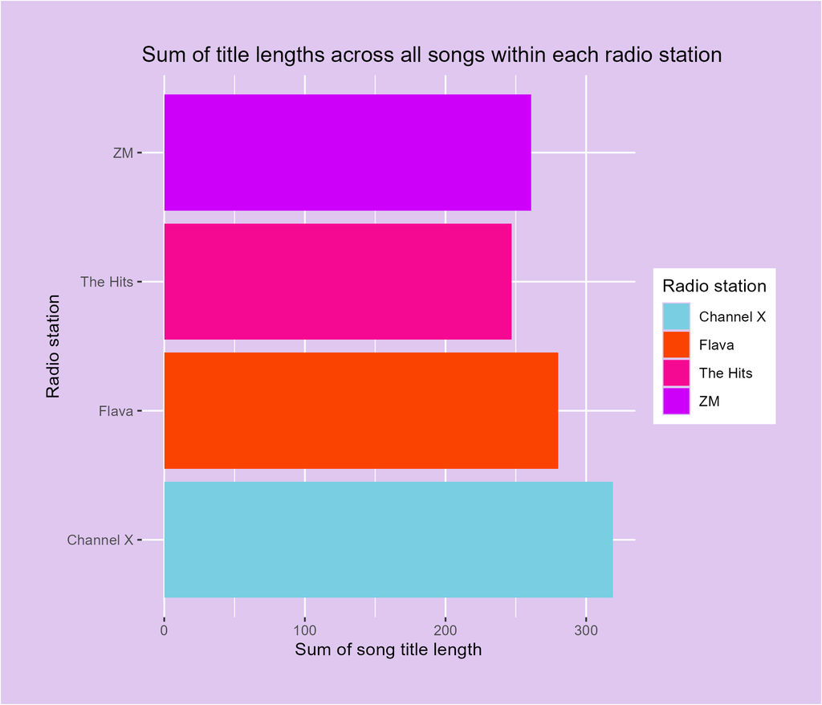

The next thing I analysed is comparing each radio station’s songs to the cumulative sum of their title lengths. Personally, I predicted that there wouldn’t be a significant difference between any of the radio stations. Overall, there actually is some difference between the radio stations, with The Hits having the lowest sum and Channel X having the highest. Also, some of the songs with long title lengths in my data are having a good influence on the results. For example, the Primitive Radio Gods song that Channel X played contains about a whopping 60 characters, which is just under 1/5th of Channel X’s total! It has greatly helped Channel X to become the winner here, with over 300 characters in total.